# Roman Shipwrecks network

Antonio Rivero Ostoic

CEDHAR, Aarhus University

jaro@cas.au.dk

25 februar 2022

This post concerns the Strauss shipwrecks database on Roman Shipwrecks network:

Strauss, J. (2013). *Shipwrecks Database*. Version 1.0. Accessed (07-12-2021) from oxrep.classics.ox.ac.uk/databases/shipwrecks_database/

Built from Parker, A.J. *Ancient Shipwrecks of the Mediterranean and the Roman Provinces* (Oxford: BAR International Series 580, 1992)

## Shipwrecks Database

Andrew Wilson coordinates a catalogue of all known ancient wrecks in the Mediterranean up to 1500 AD where there is the database from Julia Strauss’s PhD thesis *Roman Cargoes: Underwater Evidence from the East* (London 2007).

### Requirements

Install and load `R` packages to run the code snippets.

```r
library("sdam") # v0.7.4 or higher
library("readxl") # read MS Excel sheets
library("networkD3") # plot interactive graphs
library("multiplex") # v2.9.8 or higher
library("multigraph") # plot valued directed graphs
```

### Retrieving the Data

The Shipwrecks Database is distributed as a `ZIP` *filesystem* that needs a temporal file where to download it. The workflow below gives the steps in `R` with credits to [this discussion](https://stackoverflow.com/questions/3053833/).

```r
temp <- tempfile()
download.file("http://oxrep.classics.ox.ac.uk/docs/StraussShipwrecks.zip", temp)
```

Next, we make the connection with the temporal file and unzip it with the `"utils"` package into object `con`, and because `StraussShipwrecks` is an MS Excel file with different sheets, we use package `"readxl"` to recursively read the excel sheets.

```r
# connect temporal file and unzip excel file
con <- utils::unzip(temp, "StraussShipwrecks.xlsx")
```

```r
# recursively read Excel sheets
allsheets <- sapply(readxl::excel_sheets(con), simplify=FALSE, USE.NAMES=TRUE,
            function(z) readxl::read_excel(con, sheet = z))
```

Before continuing with the analysis, however, we need to close the connections and remove unused files.

```r
# close connection and garbage collection
CatchupPause <- function(Secs){
 Sys.sleep(Secs) # pause to let connection work
 closeAllConnections()
 gc()
}
# close also with temporal file
unlink(temp)
```

### Analysis

We start by looking at this database with the `"base"` `summary()` function.

```r
# content in the excel sheets
summary(allsheets)
```

```
           Length Class  Mode
Shipwrecks 35     tbl_df list
Amphorae    5     tbl_df list
```

Where we can see that actually the database contains two datasets, `Shipwrecks` and `Amphorae`, which are components having 35 and 5 variables, respectively. Also notice that package `"readxl"` stores these two data frames with a *tibble* flavour.

#### Shipwrecks Dataset

The first component of the database has the shipwrecks dataset recorded in `sw` where the variables are listed in the column names.

```r
# shipwrecks dataset and class object
sw <- allsheets$Shipwrecks
class(sw)
```

```
[1] "tbl_df"     "tbl"        "data.frame"
```

```r
# variables in dataset
colnames(sw)
```

```
 [1] "Wreck ID"                "Strauss ID"              "Name"
 [4] "Parker Number"           "Sea area"                "Country"
 [7] "Region"                  "Latitude"                "Longitude"
[10] "Min depth"               "Max depth"               "Depth"
[13] "Period"                  "Dating"                  "Earliest date"
[16] "Latest date"             "Date range"              "Mid point of date range"
[19] "Probability"             "Place of origin"         "Place of destination"
[22] "Reference"               "Comments"                "Amphorae"
[25] "Marble"                  "Columns etc"             "Sarcophagi"
[28] "Blocks"                  "Marble type"             "Other cargo"
[31] "Hull remains"            "Shipboard paraphernalia" "Ship equipment"
[34] "Estimated tonnage"       "Amphora type"
```

### Sea Areas

The shipwrecks dataset has geographical information to produce networks of relations with possible trajectories of the Roman ships. These variables are the `Sea area` of the shipwreck together with the network data in `Place of origin` and `Place of destination` that are columns 5, 20 and 21 in object `sw`.

```r
sw[ ,c(5,20:21)]
```

```
# A tibble: 1,784 x 3
   `Sea area`            `Place of origin` `Place of destination`
   <chr>                 <chr>             <chr>
 1 Adriatic              Egypt             Northern Italy
 2 Adriatic              Cos               Northern Italy
 3 Adriatic              Rhodes            Northern Italy
 4 Adriatic              Aegean            Northern Italy
 5 Adriatic              <NA>              <NA>
 6 Adriatic              Rhodes            northern Italy
 7 Adriatic              Aegean            Northern Italy
 8 Western Mediterranean Aegean via Cosa   France
 9 Tyrrhenian Sea        Aegean.           Rome
10 Adriatic              Aegean            Northern Italy
# ... with 1,774 more rows
```

There are, however, that some record entries need *cleaning* from question marks, spaces, lower/upper cases, etc. Below, we look at some examples in the dataset, and use functionalities in the `"sdam"` internal function `cln()` that removes special characters and capitalizes words to uniform the data as much as possible for further analyses.

```r
# four entries to clean
sw[c(6,9,35,130), c(5,20:21)]
```

```
# A tibble: 4 x 3
  `Sea area`            `Place of origin` `Place of destination`
  <chr>                 <chr>             <chr>
1 Adriatic              Rhodes            northern Italy
2 Tyrrhenian Sea        Aegean.           Rome
3 Aegean                Cos?              Black Sea?
4 Eastern Mediterranean Tripolitania (?)  Brega, for trans shipment (?)
```

```r
# default clean
sdam::cln(sw[c(6,9,35,130), c(5,20:21)])
```

```
               Sea area Place of origin         Place of destination
1              Adriatic          Rhodes               northern Italy
2        Tyrrhenian Sea         Aegean.                         Rome
3                Aegean             Cos                    Black Sea
4 Eastern Mediterranean Tripolitania () Brega, for trans shipment ()
```

```r
# include specific characters
cln(sw[c(6,9,35,130), c(5,20:21)], what=c("(",")"))
```

```
               Sea area Place of origin       Place of destination
1              Adriatic          Rhodes             northern Italy
2        Tyrrhenian Sea         Aegean.                       Rome
3                Aegean             Cos                  Black Sea
4 Eastern Mediterranean   Tripolitania  Brega, for trans shipment
```

```r
# raise level for dots and spaces at the end
cln(sw[c(6,9,35,130), c(5,20:21)], level=2, what=c("(",")"))
```

```
               Sea area Place of origin      Place of destination
1              Adriatic          Rhodes            northern Italy
2        Tyrrhenian Sea          Aegean                      Rome
3                Aegean             Cos                 Black Sea
4 Eastern Mediterranean    Tripolitania Brega, for trans shipment
```

```r
# also capitalize words
cln(sw[c(6,9,35,130), c(5,20:21)], level=2, what=c("(",")"), case=1)
```

```
               Sea area Place of origin      Place of destination
1              Adriatic          Rhodes            Northern Italy
2        Tyrrhenian Sea          Aegean                      Rome
3                Aegean             Cos                 Black Sea
4 Eastern Mediterranean    Tripolitania Brega, For Trans Shipment
```

The first option removes only characters `?*+`, and the second one removes also parenthesis. The command with a raised `"level"` removes also unnecessary spaces and dots at the end of each record, and `1` in `"case"` implies capitalization of just the first letter in each word.

### Network Relations

The places of origin and destination recorded in the Strauss shipwrecks dataset allows us producing a network representation of the possible trajectories of the Roman ships, and this information constitutes one kind of relation in a broader transportation system.

#### Edge List and Adjacency Matrix

```r
# clean and remove NA entries
edgel <- cln(sw[ ,20:21], level=2, what=c("(",")"), case=1, na.rm=TRUE)
```

```r
# head and tail of edge list
rbind(head(edgel), tail(edgel))
```

```
                   Place of origin      Place of destination
1                            Egypt            Northern Italy
2                              Cos            Northern Italy
3                           Rhodes            Northern Italy
4                           Aegean            Northern Italy
6                           Rhodes            Northern Italy
7                           Aegean            Northern Italy
1740             Herakleia Pontica                    Bizone
1754                       Baetica                      Rome
1755                     Lusitania                      Rome
1756 Southern Spain Via Marseilles                      Pisa
1759     Southern Levant Or Cyprus Southern Levant Or Cyprus
1765         Central Western Italy                    Aegean
```

Uses function `transf()` from `"multiplex"` to transform the edge list into the *adjacency matrix* of the network in array `mat`.

```r
# construct matrix from edge list assuming one relation
mat <- multiplex::transf(edgel, type="toarray")
```

```r
# size of matrix
dim(mat)
```

```
[1] 143 143
```

#### Graph Representation

We plot the Roman Shipwrecks network as a directed graph using a force-directed layout algorithm with `R` package `"multigraph"` and different options that allows seeing the many components in the network.

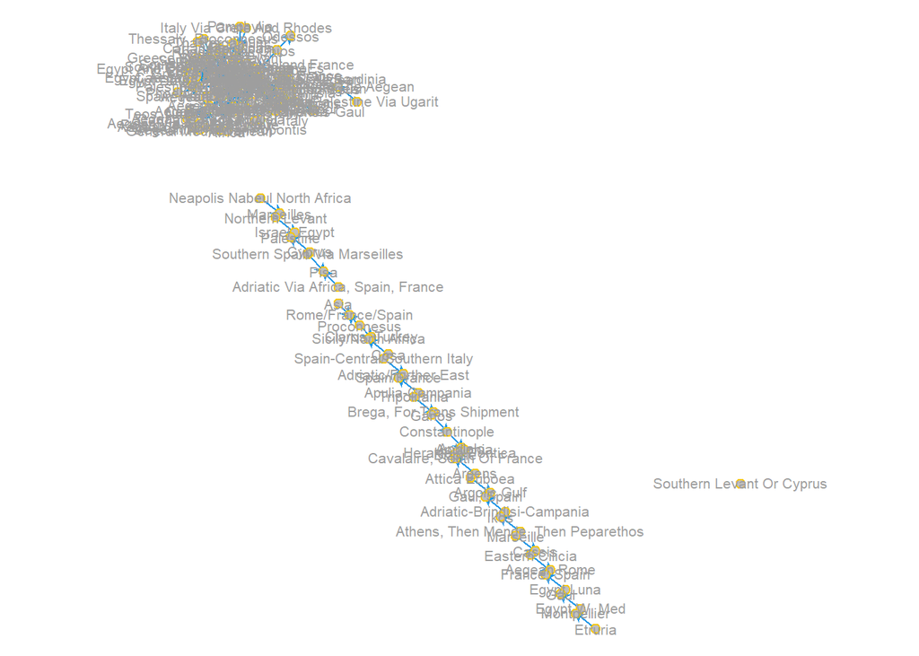

Graph for Strauss Roman Shipwrecks network.

```r
# plot customized graph
multigraph::multigraph(mat, layout="force", seed=3, ecol=4, col="#C0C0C0", vcol0=7, pos=0, fcol=8, rot=45)
```

#### Plotting with `"networkD3"`

`"networkD3"` is an `R` package popular for producing Sankey diagrams, and which uses the capabilities of `"htmlwidgets"` package. It has function `simpleNetwork()` to be able to plot networks as *‘D3 JavaScript’ network* graph allowing interactivity through a web browser. Plotting the sea regions in the Roman Shipwrecks network with this function, however, needs a data frame class object with the edge list as the input network.

```r
# edge list from adjacency matrix
elmat <- transf(mat, type="toedgel", sep="\t")
```

and look at the head of the edge list data frame

```r
head(elmat)
```

```
                                   s             r t
1         Adriatic-Brindisi-Campania   Gaul, Spain 1
2 Adriatic Via Africa, Spain, France          Pisa 1
3                           Adriatic        Aegean 1
4                           Adriatic        Aegean 1
5                           Adriatic    Alexandria 1
6                           Adriatic Cyprus/Levant 1
```

##### Interactive Graphs

Now we can plot the sea regions in the Roman Shipwrecks network with `simpleNetwork()` from `"networkD3"` using the `'zoom'` and other options to see the graph structure more easily.

```r
# zoom into a simple undirected network
networkD3::simpleNetwork(elmat, fontFamily="sans-serif", opacity=1, zoom=TRUE)
```

[interactive chart not shown]

Sea regions in Roman Shipwrecks network.

And same steps to plot the network largest component as interactive graph without zoom.

#### Network Components

Function `comps()` from package `"multiplex"` provides the network components and isolates with the relations recorded in the adjacency matrix in `mat`.

```r
# find network components
multiplex::comps(mat)
```

```
$com
$com[[1]]
[1] "A Palace In The Aegean"     "Syria/Palestine Via Ugarit"

$com[[2]]
 [1] "Aegean Tripolitania Italy"       "NA"
 [3] "Narbonne, France"                "North Africa"
 [5] "Northern Italy"                  "Odessos"
 [7] "Palestine And Elsewhere"         "Palestine Cilicia, Aegean"
 [9] "Aegean Via Cosa"                 "Palestine/Rhodes"
[11] "Pamphylia"                       "Paros"
[13] "Pergamum"                        "Phoenicia"
[15] "Rhodes"                          "Rhodes, Cos"
[17] "Rome"                            "Aegean Via Southern Italy"
[19] "Samos"                           "Sicily"
[21] "Sicily/Rome"                     "South Coast Black Sea"
[23] "South Of France"                 "South West France Inland France"
[25] "Southern Italy"                  "Aegean, Italy"
[27] "Spain"                           "Spain, Aegean, Adriatic"
[29] "Tarraconensis"                   "Teos, Naxos, Rome"
[31] "Tera"                            "Thasos"
[33] "Aegean/Africa"                   "Thasos/Asia Minor"
[35] "Thessaly, Proconnesus"           "Thessaly/Euboea"
[37] "Aegean/N. Africa/Propontis"      "Africa"
[39] "Alex/Pergamum/Aegean"            "Alexandria"
[41] "Adriatic"                        "Aquileia"
[43] "Asia Minor"                      "Assos"
[45] "Athens"                          "Athens Via Delos"
[47] "Baetica"                         "Baetica-Tarraconensis-Gaul"
[49] "Black Sea"                       "Cadiz"
[51] "Caesarea"                        "Caesarea Maritima"
[53] "Cartagena, Spain"                "Carthage"
[55] "Carthage-Spain-Sicily/Sardinia"  "Carthage Aegean"
[57] "Carystos"                        "Central Western Italy"
[59] "Chemtou, Tunisia"                "Chios"
[61] "Cnidus"                          "Corinth"
[63] "Cos"                             "Cos, Crete, Italy"
[65] "Cos, Rhodes"                     "Cos, Rhodes, Athens"
[67] "Crete"                           "Aegean"
[69] "Cyprus/Levant"                   "Docimium/Proconnesus"
```

[output cut: 63 more lines]

```
$com[[19]]
[1] "Eastern Cilicia" "Aegean Rome"

$com[[20]]
[1] "Egypt Luna"    "France, Spain"

$com[[21]]
[1] "Egypt W. Med" "Gaul"

$com[[22]]
[1] "Etruria"     "Montpellier"


$isol
[1] "Southern Levant Or Cyprus"
```

Notice that there is an isolated entity in the network; however, this is another component in the Roman Shipwrecks network having a self-relationship.

```r
require("magrittr")
mat %>%
  multiplex::bundles(loops=TRUE) %>%
  multiplex::summaryBundles() %>%
  tail(4)
```

```
                                                          Bundles
Loop1                                       o{R} (Cyprus, Cyprus)
Loop2                                         o{R} (Italy, Italy)
Loop3                                               o{R} (NA, NA)
Loop4 o{R} (Southern Levant Or Cyprus, Southern Levant Or Cyprus)
```

Part of the exploratory network analysis is to look at the dyadic relations in the system, particularly if is directed like the Roman Shipwrecks network. The two functions from `"multiplex"` used above serve to find the different bundle patterns occurring in the network.

##### Largest component

We focus on the largest component of the network, which is the second constituent in the output of `comps()` above. By selecting this component with argument `'sel'` in function `rel.sys()`, we obtain the adjacency matrix of this section as an array `'type'` object that is recorded in `matc` with has 95 nodes.

```r
# adjacency matrix of selected largest component
matc <- multiplex::rel.sys(mat, type="toarray", sel=comps(mat)$com[[2]])
```

```r
# matrix size
dim(matc)
```

```
[1] 95 95
```

Then plot the largest component in the Roman Shipwrecks network where locations and their connections are easier to see.

Plotting largest component of sea regions with `"multigraph"`:

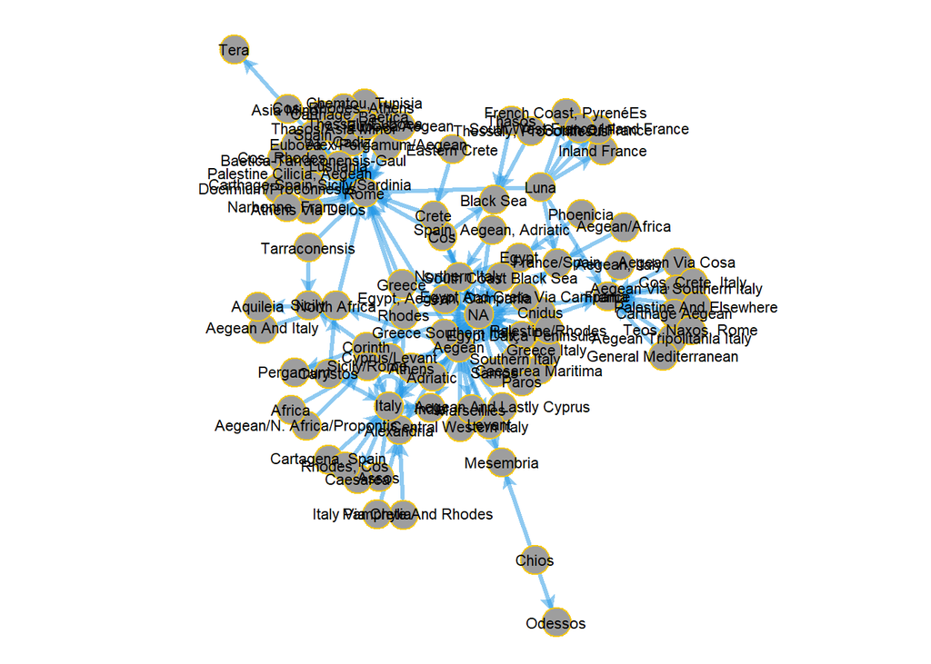

Directed graph of largest component in Roman Shipwrecks network.

```r
# graph of largest component with adjusted vertex-edge distance
multigraph(matc, loops=TRUE, layout="force", cex=3, col=8, vcol0=7, lwd=3, ecol=4, pos=0)
```

Plotting largest component of sea regions with `"networkD3"`:

```r
# largest component
simpleNetwork(transf(matc,type="toedgel",sep="\t"), fontFamily="sans-serif", opacity=1)
```

[interactive chart not shown]

Interactive graph of largest component in Roman Shipwrecks network.

## Seas in Mediterranean Basin

All locations in the two network variables of the edge list in `edgel`, which are `Place of origin` and `Place of destination`, belong to a certain sea or region in the Mediterranean Basin or neighbouring waters. One could use information from the `Sea area` variable in `sw`; however, this variable corresponds to the shipwreck locations, which in many cases are far from the origin and destination of the ship.

The following characters serve to discern clusters of origin and destination places within Strauss Roman Shipwrecks network where most sea names are in D. Hessong cartographical map (2001) deposited in an [online repository for Diplomacy information](http://www.dipwiki.com/images/5/5c/AncientMed9_Names.gif).

- **A** or **Æ**: Aegean, including Minoan Sea
- **D**: Adriatic Sea
- **I**: Ionian Sea, including Ausonian Sean and Messenian Sea
- **T**: Tyrrhenian Sea
- **B**: Baetica, including Alboran/Iberian Sea
- **L**: Ligurian Sea, including Baleares
- **E**: East, from Cilician Strait through Levante Basin
- **F**: Africa, including Libyan Sea and Cyrene
- **P**: Punic Sea, including Berber Sea
- **C**: Black Sea
- **G**: Gaul
- **X**: India

Because some locations entries in this dataset are vague, the clustering information for the places of origin and destination for the reduction of the network result ambiguous with entries having more than one letter.

The assignation of *Sea Regions* to the places of origin and destination was made by hand and are recorded in a tabular separated table in file `ShipwreckSeas.txt`. To load this file into object `ss` we need to specify the separator of the data that in this case has a header.

```r
# read file with Mediterranean sea regions per place
ss <- read.table(file="ShipwreckSeas.txt", header=TRUE, sep="\t")
```

An excerpt of `ss` given below illustrates the location ambiguity in the data. For instance, `Aegean And Italy` in entry 8 imply three possible region seas that are Aegean, Ionian, and Adriatic; however, `Aegean Rome` in entry 10 implies the west coast of the Italian peninsula. In this case, the sea region corresponds to the Tyrrhenian Sea rather than the east coast facing the Adriatic.

```r
# excerpt with 9 sea regions
ss[8:16,]
```

```
                        PLACE  CODE
8            Aegean And Italy A,D,I
9    Aegean And Lastly Cyprus   A,E
10                Aegean Rome A,T,I
11  Aegean Tripolitania Italy A,D,I
12            Aegean Via Cosa     A
13  Aegean Via Southern Italy   A,I
14              Aegean, Italy A,D,I
15              Aegean/Africa   A,F
16 Aegean/N. Africa/Propontis   A,F
```

### Network Reduction

A clustering information serves to reduce the network into related sets of equivalent places in the system.

```r
# matching sea regions to the edge list
ss[c(head(match(edgel[,1], ss$PLACE),3), tail(match(edgel[,1], ss$PLACE),3)),]
```

```
                            PLACE CODE
73                          Egypt    E
60                            Cos    A
137                        Rhodes    A
153 Southern Spain Via Marseilles    B
152     Southern Levant Or Cyprus    E
53          Central Western Italy    T
```

Then we create a newdata frame `edgelc` with sea region codes in `ss`, which are in columns `from` and `to`.

```r
# data frame with codes
edgelc <- cbind(edgel, from=ss[match(edgel[,1], ss$PLACE),]$CODE,
                       to=ss[match(edgel[,2], ss$PLACE),]$CODE)
```

```r
# look at first entries
head(edgelc)
```

```
  Place of origin Place of destination from  to
1           Egypt       Northern Italy    E L,D
2             Cos       Northern Italy    A L,D
3          Rhodes       Northern Italy    A L,D
4          Aegean       Northern Italy    A L,D
6          Rhodes       Northern Italy    A L,D
7          Aegean       Northern Italy    A L,D
```

Unique labels in origin and destination of sea regions are

```r
# from sea region
unique(edgelc$from)
```

```
 [1] "E"       "A"       "A,F"     NA        "E,A"     "C"       "T,I,D"   "D"       "A,I"
[10] "I"       "A,D,I"   "A,E"     "P"       "M"       "T"       "L"       "B,L,A,D" "A,I,T"
[19] "P,I,A"   "F"       "B,L,I"   "B"       "I,F"     "B,L"
```

```r
# to sea region
unique(edgelc$to)
```

```
 [1] "L,D"   "L,G"   "T"     "I,T"   "A"     NA      "A,T,I" "C"     "T,I,D" "E"     "F"     "X"
[13] "L"     "B"     "I,P"   "G"     "T,L"   "D"     "B,L,G"
```

#### Sea Regions Origin and Destination

The adjacency matrix of letters in `mat0` comes from columns `from` and `to` in edge list `edgelc` and are located in column positions 3 and 4.

```r
# ties in sea regions
mat0 <- transf(edgelc[,3:4], type="toarray")
```

and then plot the multigraph of the reduced structure.

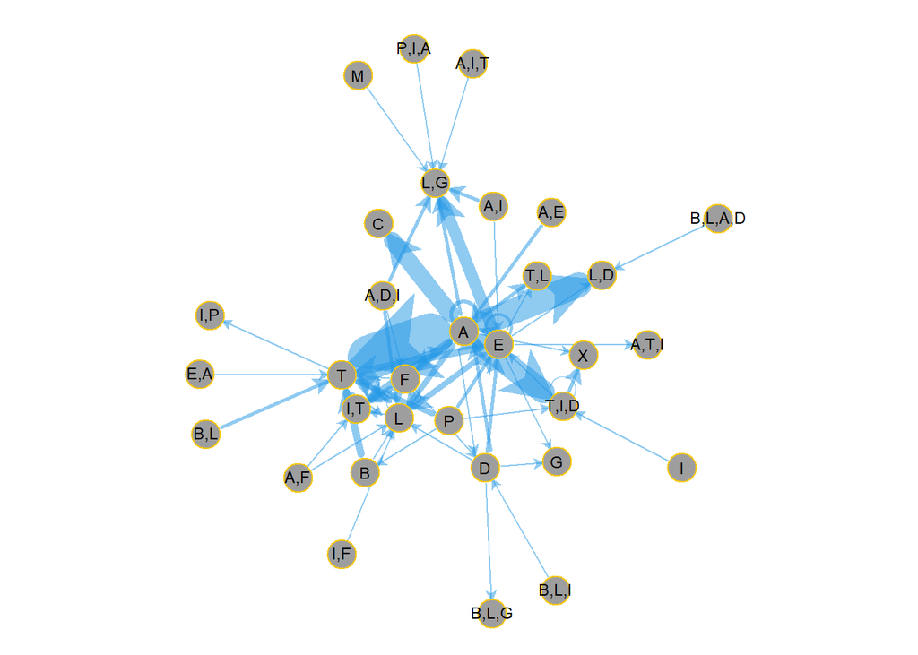

Sea regions in the Roman Shipwrecks network as valued graph.

```r
# list of characteristics
scp <- list(valued=TRUE, loops=TRUE, cex=3, pos=0, ecol=4, col=8, vcol0=7, alpha=c(1,.5))

# force-directed with random seed
multigraph(mat0, scope=scp, layout="force")
```

To plot the reduced structure with `simpleNetwork()` from `"networkD3"` on an edge list from its adjacency matrix.

```r
simpleNetwork(transf(mat0,type="toedgel"), fontFamily="sans-serif", opacity=1)
```

[interactive chart not shown]

Sea regions simple plot.

## Time, Dates and Dating

There are variables in the Roman shipwrecks dataset related to time where `'Earliest date'` and `'Latest date'` delimit the timespans of existence. The other two time related variables having data are `'Period'` and `'Dating'`, while `"Date range"`, `"Mid point of date range"`, and `"Probability"` do not contain any data in `sw`.

```r
colnames(sw)[13:19]
```

```
[1] "Period"                  "Dating"                  "Earliest date"
[4] "Latest date"             "Date range"              "Mid point of date range"
[7] "Probability"
```

### Timespans of Existence

Use function `plot.dates()` from package `"sdam"` to plot the timespans of existence of the shipwrecks dataset with the delimiting variables for the *terminus ante quem* and *terminus post quem* as `taq` and `tpq`, respectively.

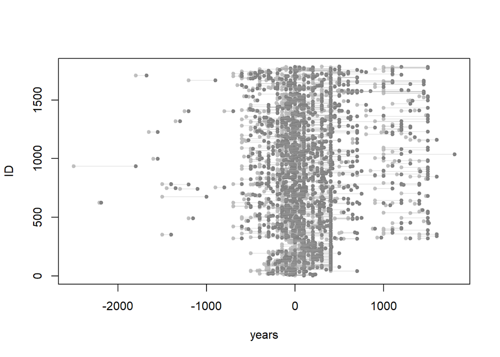

Shipwrecks timespans of existence

```r
# plot shipwrecks timespans
sdam::plot.dates(sw, taq="Earliest date", tpq="Latest date")
```

Alternatively, plot with `plot.dates()` using the two IDs existing in the dataset, which are `Wreck ID` and `Strauss ID`.

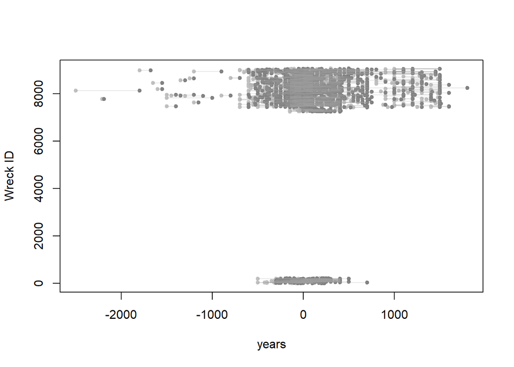

```r
# use Wreck ID
plot.dates(sw, id="Wreck ID",
           taq="Earliest date", tpq="Latest date")
```

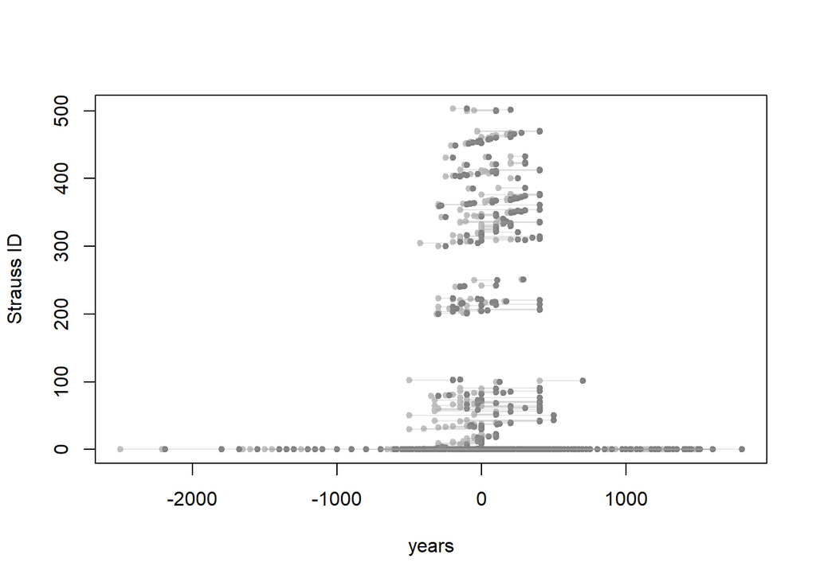

```r
# use Strauss ID
plot.dates(sw, id="Strauss ID",
           taq="Earliest date", tpq="Latest date")
```

### Aoristic sum

The *aoristic sum* is a proxy to compute the probability of existence of a given artefact.

Use function `prex()` computes the aoristic sum of the shipwrecks dataset that is visualized as bar plots with an 8 bin chronological phases `'cp'`.

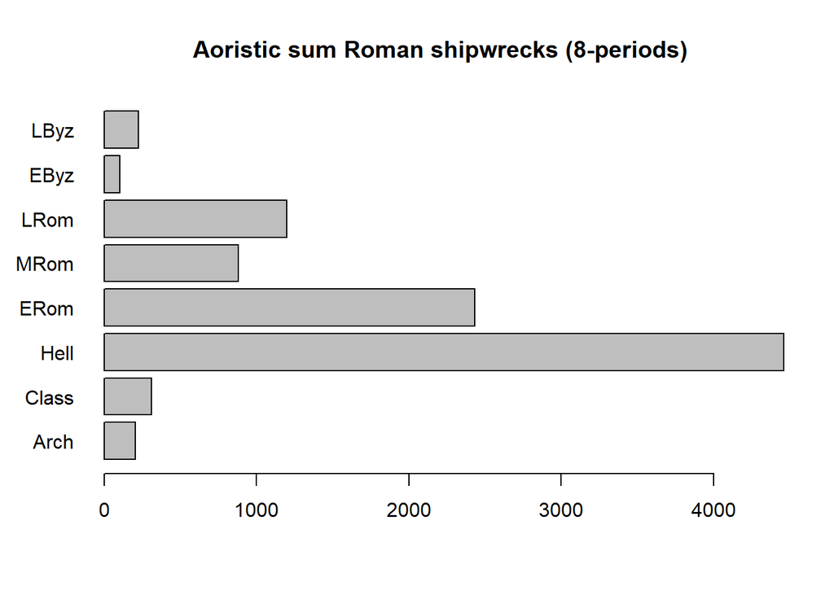

```r
# plot aoristic sum
require("magrittr")
sw %>%
  sdam::prex(taq="Earliest date", tpq="Latest date", cp="bin8") %>%
  barplot(horiz=TRUE, las=1, main="Aoristic sum Roman shipwrecks (8-periods)")
```

The chronological phases for dating ancient cultures of the Mediterranean are adapted from Bevan et al, 2013.

### Period

Chronological periods are used for dating purposes, and in the shipwrecks dataset, as such, there are 71 unique entries for this variable in `sw`.

```r
# levels in variable
require("magrittr")
sw$Period %>%
  unique() %>%
  length()
```

```
[1] 71
```

However, the dataset needs to be “cleaned” since some unique entries belong to the same period.

```r
unique(sw$Period)[c(6,12)]
```

```
[1] "Classical/Hellenistic"   "Classical / Hellenistic"
```

In fact, an automatic cleaning using function `cln()` shorts the unique entries for the `'Period'` variable.

```r
# levels in variable after cleaning
require("magrittr")
sw$Period %>%
  cln(case=1,level=2) %>%
  unique() %>%
  length()
```

```
[1] 60
```

With this modifications, the two above periods become a single level.

```r
"Classical/Hellenistic"
```

### Dating

The last time related variable in the shipwrecks dataset recorded in `sw` is `'Dating'` where some entries are:

```r
tail(sw$Dating)
```

```
[1] "C1st-2nd AD"   "C5th AD"       "C11th-15th AD" "C1st BC"       "C12th AD"      "C4th-5th AD"
```

Dealing with dating data is the aim of the `"sdam"` function `dts()`.

### See also

- [Centrality measures in ORBIS Roman transport network](https://htmlpreview.github.io/?https://github.com/sdam-au/R_code/blob/master/HTML/Centrality%20measures%20in%20ORBIS%20Roman%20transport%20network.html)
- [ORBIS Roman World transport network](https://htmlpreview.github.io/?https://github.com/sdam-au/R_code/blob/master/HTML/ORBIS%20Roman%20World%20transport%20network%20centrality%20measures.html)
- [Plotting Roman Empire transport network](https://sdam-au.github.io/sdam/articles/TransportNetwork.html)
- [Plotting ancient Roman provinces and regions](https://sdam-au.github.io/sdam/articles/RomanProvs.html)
- [Re-encoding Greek characters from ‘EDH’ dataset](https://sdam-au.github.io/sdam/articles/Encoding.html)
- [`"sdam"` manual](https://github.com/mplex/cedhar/blob/master/typesetting/reports/sdam.pdf)
- [Social Dynamics and complexity in the Ancient Mediterranean Project](https://sdam-au.github.io/sdam-au/)